# Lab5 ERGMs

## Specifying a ERGM Model

Within R, easily the most comprehensive and sophisticated package for ERGMs is the **ergm** package, which is part of the **statnet** suite of packages.4 Since **ergm** uses the network package to represent network objects, we convert the **igraph** object lazega to the format used in statnet, first separating the network into adjacency matrix and attributes

```r
library(sand)
data(lazega)
A <- get.adjacency(lazega)
v.attrs <- get.data.frame(lazega, what="vertices")
```

and then creating the analogous network object for **ergm**8

```r
library(ergm)
lazega.s <- network::as.network(as.matrix(A), directed=FALSE)
network::set.vertex.attribute(lazega.s, "Office", v.attrs$Office)
network::set.vertex.attribute(lazega.s, "Practice", v.attrs$Practice)
network::set.vertex.attribute(lazega.s, "Gender", v.attrs$Gender)
network::set.vertex.attribute(lazega.s, "Seniority", v.attrs$Seniority)
```

For example, Bernoulli model may be specified for the network `lazega.s` as

```r
my.ergm.bern <- formula(lazega.s ~ edges)
my.ergm.bern
```

```
## lazega.s ~ edges
```

```r
summary.statistics(my.ergm.bern)
```

```
## edges
##   115
```

For k-star models

```r
my.ergm <- formula(lazega.s ~ edges + kstar(2)+ kstar(3) + triangle)
summary.statistics(my.ergm)
```

```
##    edges   kstar2   kstar3 triangle
##      115      926     2681      120
```

For alternating sums of k-triangles,

```r
my.ergm <- formula(lazega.s ~ edges+ gwesp(1, fixed=TRUE))
summary.statistics(my.ergm)
```

```
##         edges gwesp.fixed.1
##      115.0000      213.1753
```

Main effects and second-order effects may be incorporated into a model within ergm using the terms nodemain and nodematch, respectively.

```r
lazega.ergm <- formula(lazega.s ~ edges + gwesp(log(3), fixed=TRUE)
+ nodemain("Seniority")
+ nodemain("Practice")
+ match("Practice") + match("Gender") + match("Office"))
```

## Model Fitting

In **ergm**, models are fit using the function `ergm`, which implements a version of Markov chain Monte Carlo maximum likelihood estimation.

```r
set.seed(42)
lazega.ergm.fit <- ergm(lazega.ergm)
anova(lazega.ergm.fit)
```

```
## Analysis of Variance Table
##
## Model 1: lazega.s ~ edges + gwesp(log(3), fixed = TRUE) + nodemain("Seniority") +
##     nodemain("Practice") + match("Practice") + match("Gender") +
##     match("Office")
##          Df Deviance Resid. Df Resid. Dev Pr(>|Chisq|)
## NULL                       630     873.37
## Model 1:  7   413.45       623     459.92    < 2.2e-16 ***
## ---
## Signif. codes:  0 '***' 0.001 '**' 0.01 '*' 0.05 '.' 0.1 ' ' 1
```

Similarly, we can examine the relative contribution of the individual variables in our model.

```r
summary.ergm(lazega.ergm.fit)
```

```
##
## ==========================
## Summary of model fit
## ==========================
##
## Formula:   lazega.s ~ edges + gwesp(log(3), fixed = TRUE) + nodemain("Seniority") +
##     nodemain("Practice") + match("Practice") + match("Gender") +
##     match("Office")
##
## Iterations:  2 out of 20
##
## Monte Carlo MLE Results:
##                               Estimate Std. Error MCMC % z value Pr(>|z|)
## edges                        -7.012653   0.703068      0  -9.974  < 1e-04
## gwesp.fixed.1.09861228866811  0.590603   0.086673      0   6.814  < 1e-04
## nodecov.Seniority             0.024716   0.006358      0   3.888 0.000101
## nodecov.Practice              0.396037   0.104274      0   3.798 0.000146
## nodematch.Practice            0.769497   0.196117      0   3.924  < 1e-04
## nodematch.Gender              0.737421   0.246394      0   2.993 0.002764
## nodematch.Office              1.165442   0.190538      0   6.117  < 1e-04
##
## edges                        ***
## gwesp.fixed.1.09861228866811 ***
## nodecov.Seniority            ***
## nodecov.Practice             ***
## nodematch.Practice           ***
## nodematch.Gender             **
## nodematch.Office             ***
## ---
## Signif. codes:  0 '***' 0.001 '**' 0.01 '*' 0.05 '.' 0.1 ' ' 1
##
##      Null Deviance: 873.4  on 630  degrees of freedom
##  Residual Deviance: 459.9  on 623  degrees of freedom
##
## AIC: 473.9    BIC: 505    (Smaller is better.)
```

## Goodness-of-Fit

To assess the goodness-of-fit of our model, as fit by ergm, the function gof in ergm runs the necessary Monte Carlo simulation and calculates comparisons with the original network graph in terms of the distribution of degree, geodesic length, and edge-wise shared partners (i.e., the number of neighbors shared by a pair of vertices defining an edge).

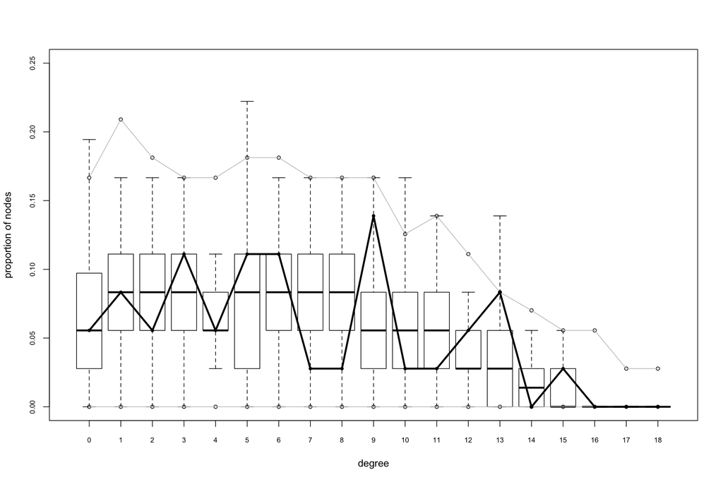

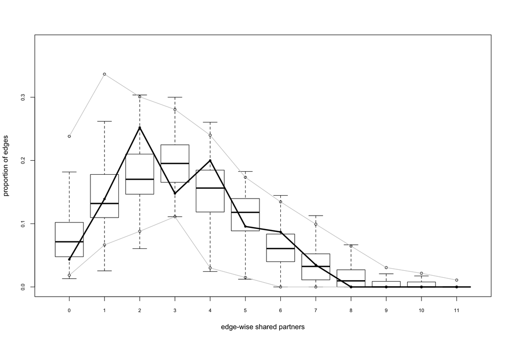

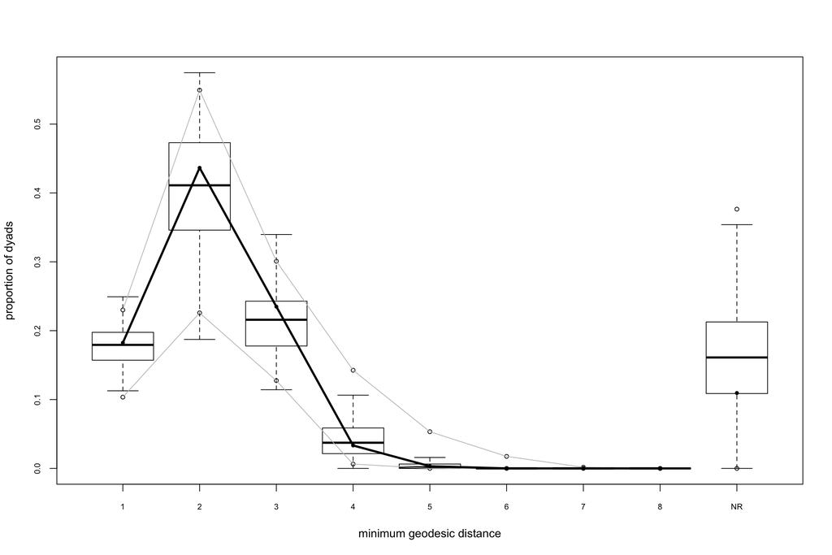

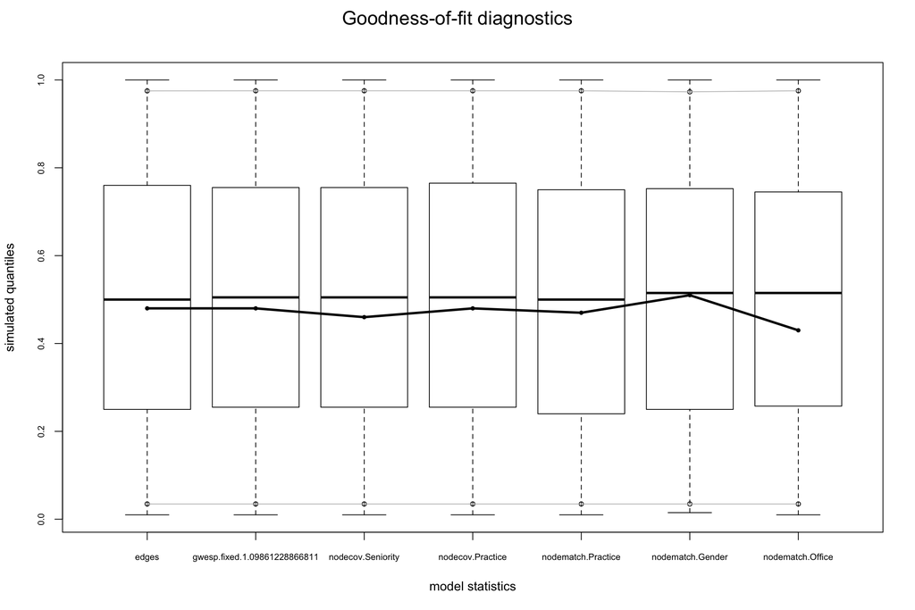

```r
gof.lazega.ergm <- gof(lazega.ergm.fit)
plot(gof.lazega.ergm)
```